# Intro to Visualization with ggplot2

##### Continuous and Discrete Variables

Let’s define graphs with two mappings, with `group = dose` in one and `group = supp` for the other.

```r
p_dose = ggplot(ToothGrowth, aes(y = len, group = dose))
p_supp = ggplot(ToothGrowth, aes(y = len, group = supp))
```

Here, we use `geom_boxplot` to generate boxplots grouped by `dose` and `supp`.

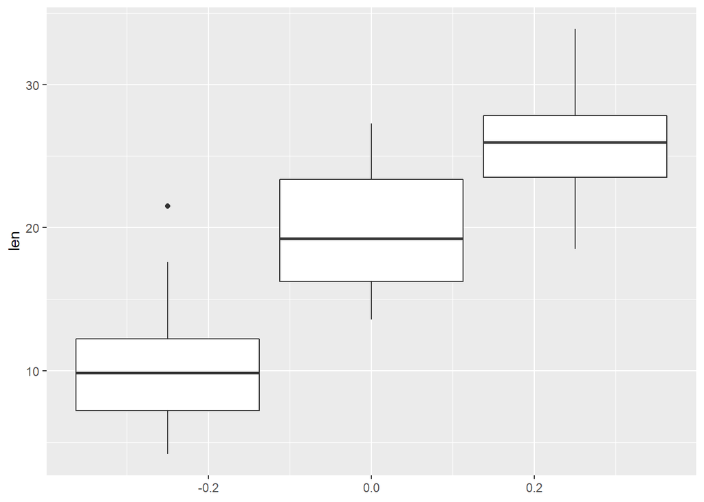

```r
p_dose + geom_boxplot()
```

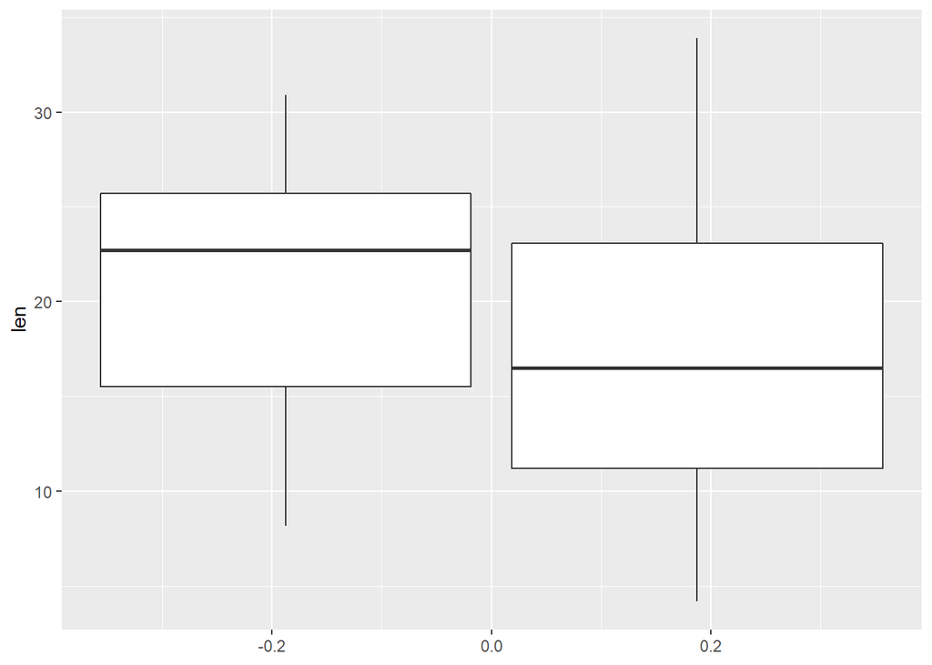

```r
p_supp + geom_boxplot()
```

Note that a boxplot generated withone continuous variable is also valid!

`geom_violin` is a similar plot, but calculates and plots density as a continuous value found with a kernel function as opposed to by quartile.

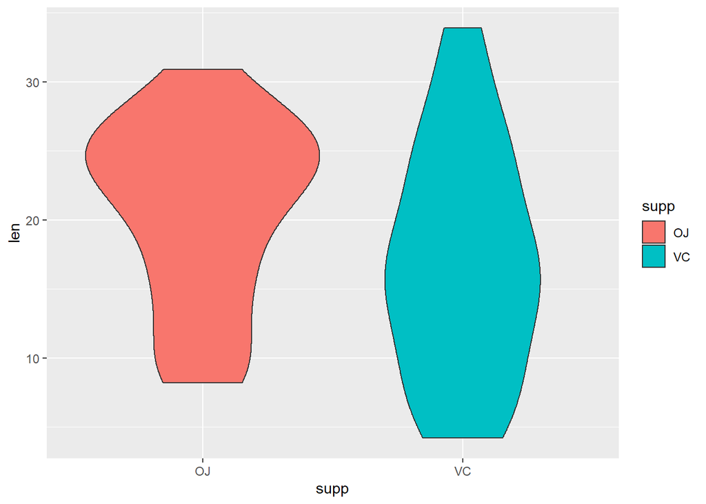

```r
p_supp = ggplot(ToothGrowth, aes(y = len, x = supp, fill = supp))

p_supp + geom_violin()
```

And of course, we can make a bar plot.

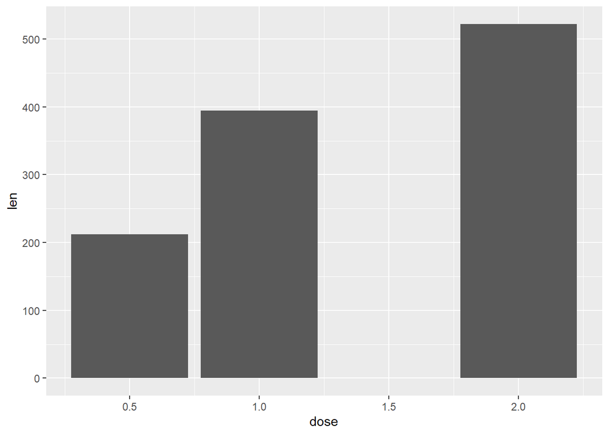

```r
ggplot(ToothGrowth, aes(y = len, x = dose))+geom_col(stat = "count")
```

#### Two Discrete Variables

The most common representation of data defined by two categorical variables is a heatmap! While we cover the base `heatmap` function in the class, you can also make one with `ggplot2`, albeit with a few extra steps.

We first use the `table` function to generate a frequency table for our variables. We then use the output of this to generate a data frame with three columns, where the first two describe all possible combinations of discrete variables (found with the `expand.grid` function), and the third is a flattened version of the frequency table, found with the `matrix` function. Note that, to ensure that frequency values match their original categories after flattening, pass the rows to `expand.grid` before columns. We then pass this data frame to ggplot, set `fill` to the frequency column, and apply the `geom_tile` geometry.

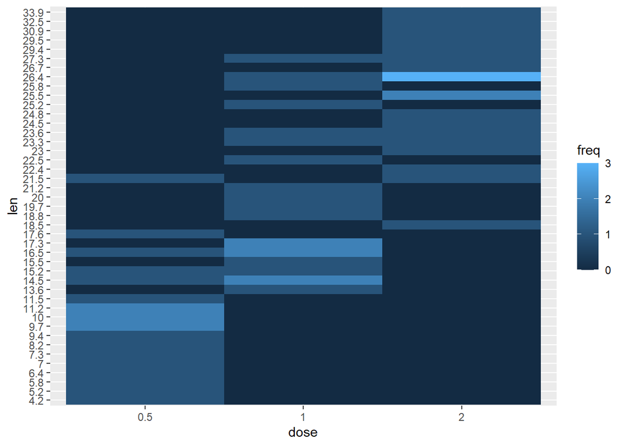

```r
tooth_freq = table(ToothGrowth[,c("len","dose")])
heatmap_df = data.frame(expand.grid(len = rownames(tooth_freq),
                                    dose = colnames(tooth_freq)),
                        freq = matrix(tooth_freq))
ggplot(heatmap_df, aes(x = dose, y = len, fill = freq)) + geom_tile()
```

### Miscellaneous

#### Setting the frame size

There are often cases in which we want to limit the data shown along the axes of a graph. There are two common ways to subset the visible area. `coord_cartesian` subsets the visible area without modifying the underlying data.

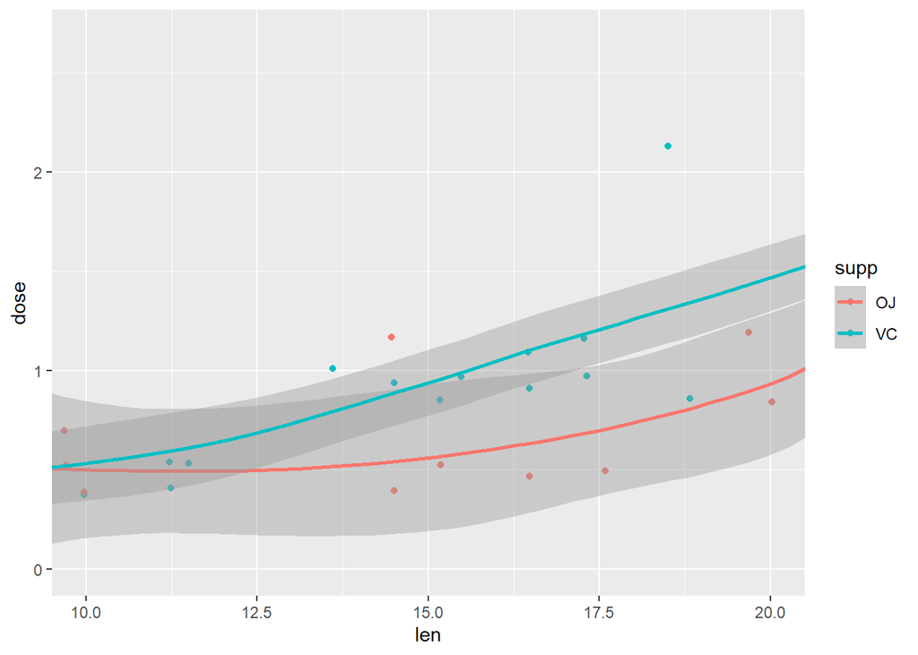

```r
ex_plot = ggplot(ToothGrowth, aes(x = len, y = dose, color = supp)) + geom_jitter() + geom_smooth()

ex_plot+ coord_cartesian(xlim = c(10,20))
```

Directly using the `xlim` and `ylim` functions instead subsets the data, and consequently the plot itself.

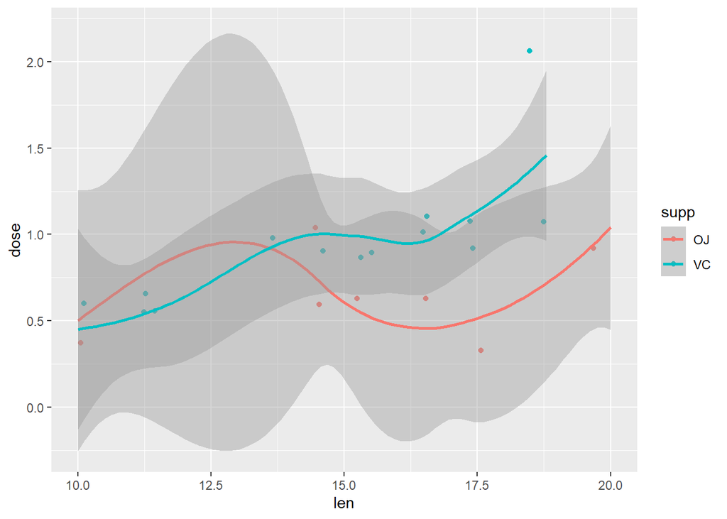

```r
ex_plot +xlim(10,20)
```

Note that the envelopes generated by these methods look pretty different! That’s because the data used to generate the plot matters especially in cases in which features learned from the data are overlaid. Here, the smoothing calculation has a much more limited set of data to train on and is therefore less smooth than the original. So, pick your viewable area wisely!

#### Graphing functions

Somtimes (especially when attempting to fit a model to data) we want to superimpose a function over a plot. This is easy with `stat_function`, which is passed an anonymous function. Note that, if there isn’t any underlying data, we should specify the `xlim`.

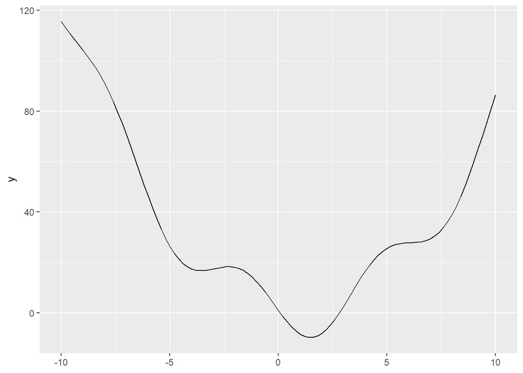

```r
ggplot() + stat_function(fun = function(x){x^2-2*x+1-10*sin(x)}) + xlim(-10,10)
```

### Labels

We often want to change our title, subtitle, or axis labels from the automatically generated ones. Luckily, we can use the `ggtitle`, `xlab,` and `ylab` functions to change any of these features by passing our new text to the correct parameters.

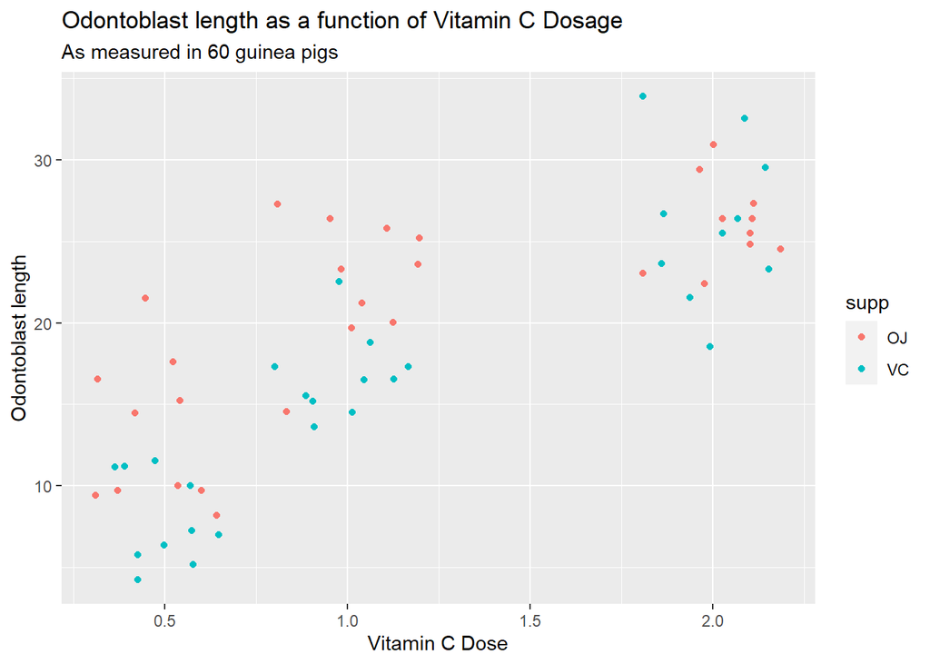

```r
p_2_c + geom_jitter() + ggtitle("Odontoblast length as a function of Vitamin C Dosage",
              subtitle = "As measured in 60 guinea pigs") +
              xlab("Vitamin C Dose") +
              ylab("Odontoblast length")
```

We can also move or remove the legend by passing one of “top”,“bottom”,“left”,“right”, or “none” to the `legend.position` parameter of the `theme` function.

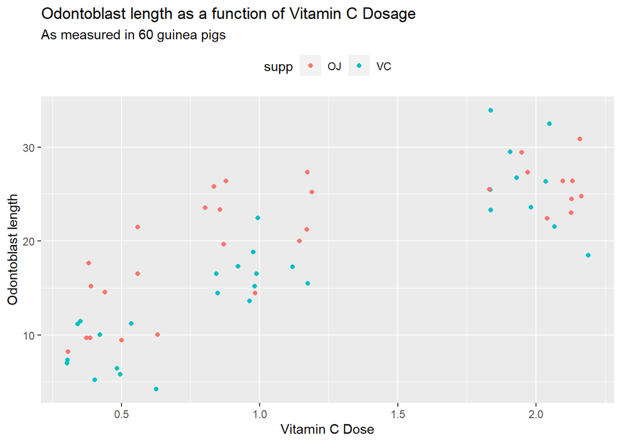

```r
p_2_c + geom_jitter() + ggtitle("Odontoblast length as a function of Vitamin C Dosage",
              subtitle = "As measured in 60 guinea pigs") +
              xlab("Vitamin C Dose") +
              ylab("Odontoblast length") +
  theme(legend.position = "top")
```

### Themes

One of the coolest parts of `ggplot2` is the number of freely available plot themes! There really are predesigned themes in any style that you would want, if you look hard enough. Here are a few found in the `ggthemes` package.

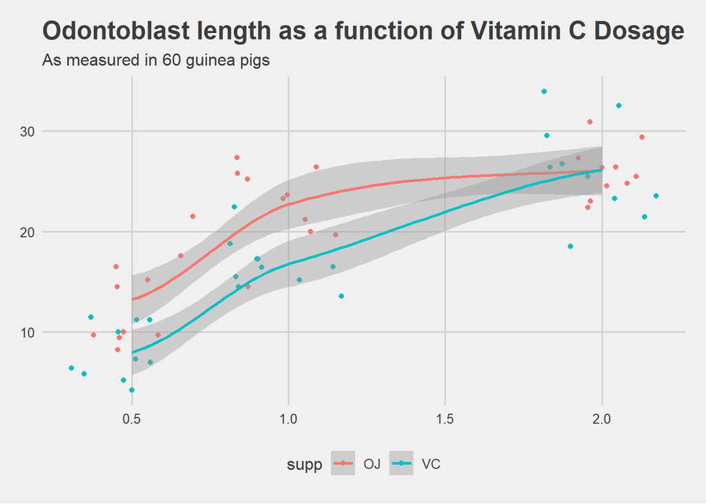

```r
library(ggthemes)
base_plot = p_2_c + geom_jitter() + geom_smooth() + ggtitle("Odontoblast length as a function of Vitamin C Dosage",
              subtitle = "As measured in 60 guinea pigs") +
              xlab("Vitamin C Dose") +
              ylab("Odontoblast length")

base_plot + theme_fivethirtyeight()
```

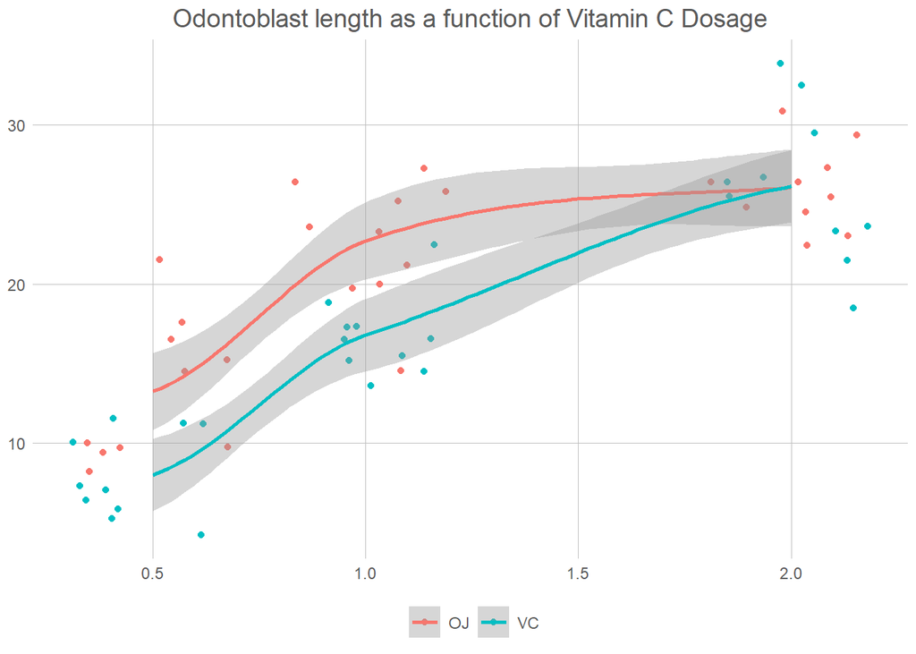

```r
base_plot + theme_excel_new()
```

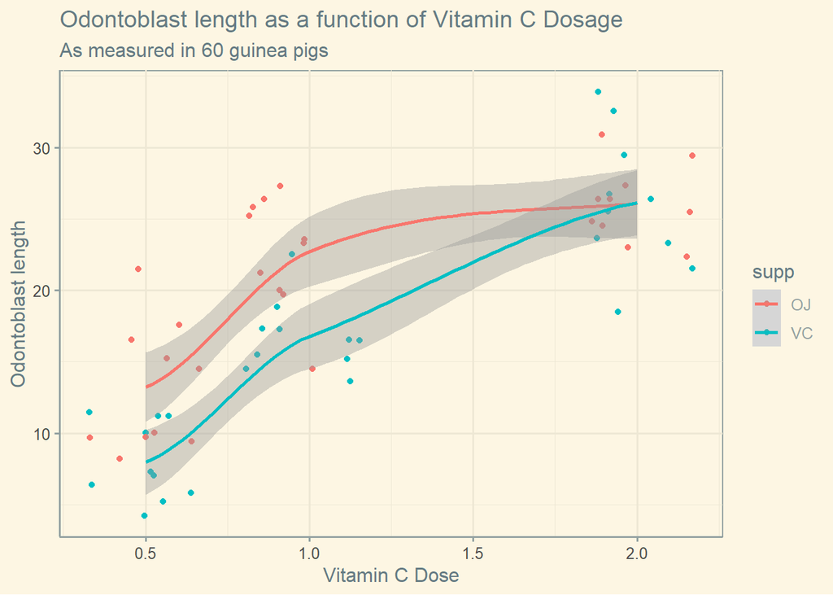

```r
base_plot + theme_solarized()
```

## Additional Resources

This tutorial was not very exhaustive, and you will likely need to learn a few additional features if you plot a lot. Included below are a few resources I refer to. I hope they can help you too!

- [The ggplot2 website](https://ggplot2.tidyverse.org/index.html)
- [The official ggplot2 cheat sheet](https://github.com/rstudio/cheatsheets/blob/master/data-visualization-2.1.pdf)
- [A walkthrough with lots of nested tutorials](http://www.sthda.com/english/wiki/ggplot2-essentials)